# Homework #5

Kobe Pranivong; illuminobe

4/10/2020

## Liquor Sales in Iowa

This dataset https://data.iowa.gov/Sales-Distribution/2019-Iowa-Liquor-Sales/38x4-vs5h contains the spirits purchase information of Iowa Class “E” liquor licensees by product and date of purchase for 2019. The dataset can be used to analyze total spirits sales in Iowa of individual products at the store level.

**Submission instructions**: Create a folder named `ds202_hw5`, and name the RMarkDown file including your solutions `hw5.Rmd` under this folder. For the submission, create a GitHub repository named `ds202_hw5` under your GitHub account, and push both `hw5.Rmd` and the knitted `hw5.html` before the deadline. I will assume you use the same GitHub username as for your HW4 submission. The latest version of your homework appearing on GitHub before the deadline is graded. *It is crucial to follow the exact folder structure and file names*, so that your homework can be reproduced and graded by an automated script. This homework is **due on April 10** by 11:59 pm.

1. The complete dataset is too large. Download and import the alcohol sales data for Ames only:
1. Go to https://data.iowa.gov/Sales-Distribution/2019-Iowa-Liquor-Sales/38x4-vs5h
2. Click Filter – Filter – Go advanced now
3. Add a New Filter Condition: City is Ames.
4. Export – CSV – Download
5. Use `readr::read_csv` to import.

```r
df = readr::read_csv("2019_Iowa_Liquor_Sales.csv")
```

2. Data cleaning:
1. extract geographic latitude and longitude from the variable `Store Location`

```r
# Cleaning up the Store Location column so it's easier to extract
df$'Store Location' <- gsub("POINT \\(", "",df$'Store Location')
df$'Store Location' <- gsub("\\)", "", df$'Store Location')
# Extracting longitude and latitude from Store Location
iaLiquorSales <- df
iaLiquorSales <- iaLiquorSales %>%
  separate('Store Location', into = c("Longitude", "Latitude"), sep = " ")
```

2. make sure the variables are in the correct type, by converting incorrect variable types.

```r
# Checking out the variables to see if they're all the correct types
iaLiquorSales %>% str # It looks like Longitude, Latitude, and Vendor Number are not the correct variable types
```

```
## Classes 'tbl_df', 'tbl' and 'data.frame':    63103 obs. of  25 variables:
##  $ Invoice/Item Number  : chr  "INV-16712000040" "INV-16712000012" "INV-16712000070" "INV-16712000009" ...
##  $ Date                 : chr  "01/03/2019" "01/03/2019" "01/03/2019" "01/03/2019" ...
##  $ Store Number         : num  2500 2500 2500 2500 2500 ...
##  $ Store Name           : chr  "Hy-Vee Food Store #1 / Ames" "Hy-Vee Food Store #1 / Ames" "Hy-Vee Food Store #1 / Ames" "Hy-Vee Food Store #1 / Ames" ...
##  $ Address              : chr  "3800 W Lincoln Way" "3800 W Lincoln Way" "3800 W Lincoln Way" "3800 W Lincoln Way" ...
##  $ City                 : chr  "Ames" "Ames" "Ames" "Ames" ...
##  $ Zip Code             : num  50010 50010 50010 50010 50010 ...
##  $ Longitude            : chr  NA NA NA NA ...
##  $ Latitude             : chr  NA NA NA NA ...
##  $ County Number        : num  85 85 85 85 85 85 85 85 85 85 ...
##  $ County               : chr  "STORY" "STORY" "STORY" "STORY" ...
##  $ Category             : num  1042100 1012100 1031100 1012100 1081400 ...
##  $ Category Name        : chr  "Imported Dry Gins" "Canadian Whiskies" "American Vodkas" "Canadian Whiskies" ...
##  $ Vendor Number        : chr  "260" "260" "055" "260" ...
##  $ Vendor Name          : chr  "DIAGEO AMERICAS" "DIAGEO AMERICAS" "SAZERAC NORTH AMERICA" "DIAGEO AMERICAS" ...
##  $ Item Number          : num  28867 11294 37936 10805 82867 ...
##  $ Item Description     : chr  "Tanqueray Gin" "Crown Royal" "Skol Vodka" "Crown Royal Regal Apple" ...
##  $ Pack                 : num  12 24 12 24 12 12 6 6 12 12 ...
##  $ Bottle Volume (ml)   : num  1000 375 750 375 1000 750 1750 1750 750 375 ...
##  $ State Bottle Cost    : num  15.5 8 3.64 8 7.87 ...
##  $ State Bottle Retail  : num  23.25 12 5.46 12 11.81 ...
##  $ Bottles Sold         : num  12 4 12 4 12 3 6 12 2 4 ...
##  $ Sale (Dollars)       : num  279 48 65.5 48 141.7 ...
##  $ Volume Sold (Liters) : num  12 1.5 9 1.5 12 2.25 10.5 21 1.5 1.5 ...
##  $ Volume Sold (Gallons): num  3.17 0.39 2.37 0.39 3.17 0.59 2.77 5.54 0.39 0.39 ...
```

```r
# Converting them to their correct variable types
iaLiquorSales[, "Longitude"] <- lapply(iaLiquorSales[, "Longitude"], as.numeric)
iaLiquorSales[, "Latitude"] <- lapply(iaLiquorSales[, "Latitude"], as.numeric)
iaLiquorSales[, "Vendor Number"] <- lapply(iaLiquorSales[, "Vendor Number"], as.numeric)
```

3. extract year, month and day from the variable `Date` as separate columns.

```r
# Extracting Month, Day, and Year from Date
iaLiquorSales <- iaLiquorSales %>%
  mutate(`Copy Date` = Date) %>%
  separate(`Copy Date`, into = c("Month", "Day", "Year"), sep = "/")
# Converting them to their correct variable types
iaLiquorSales[, "Month"] <- lapply(iaLiquorSales[, "Month"], as.numeric)
iaLiquorSales[, "Day"] <- lapply(iaLiquorSales[, "Day"], as.numeric)
iaLiquorSales[, "Year"] <- lapply(iaLiquorSales[, "Year"], as.numeric)
iaLiquorSales$Date <- as.Date(iaLiquorSales$Date, "%m/%d/%Y")
```

3. First overview:
1. Plot a scatterplot of lat and long of store locations.

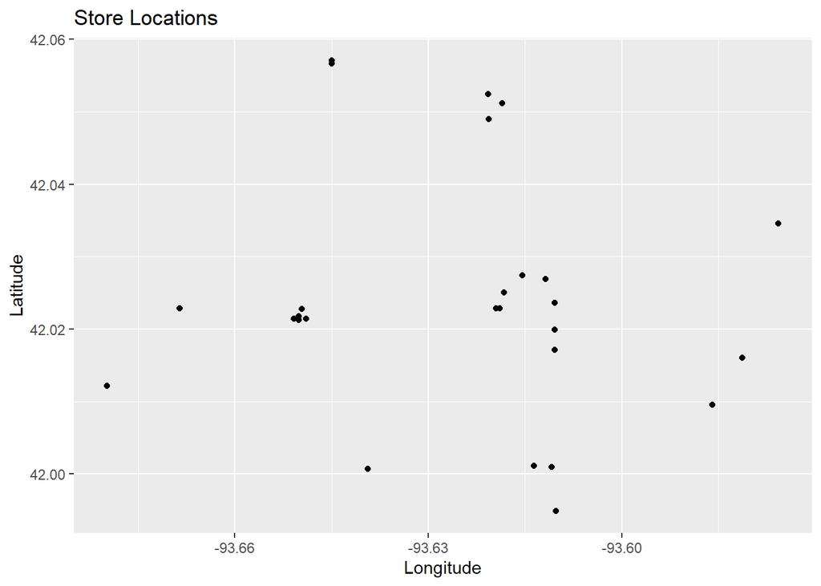

```r
iaLiquorSales %>% ggplot(aes(x = Longitude, y = Latitude)) + geom_point() + xlab("Longitude") + ylab("Latitude") + ggtitle("Store Locations")
```

2. Provide a visual breakdown of the liquor category (by `Category Name`). Include volume sold in the breakdown.

[figure not shown]

```r
iaLiquorSales %>%
  group_by(`Category Name`) %>%
  summarise(total_vol = sum(`Volume Sold (Liters)`)) %>%
  ggplot(mapping = aes(x = `Category Name`, y = total_vol, fill = `Category Name`)) + geom_col() + coord_flip() + xlab("Liquor") + ylab('Volume Sold (Liters)') + ggtitle('Liquor Category by Volume Sold (Gallons)') +   theme(legend.position = "none")
```

4. Find the daily sales liquor sales in Ames in 2019. Summarize the number of sales, volume of liquor sold, and amount of money spent.

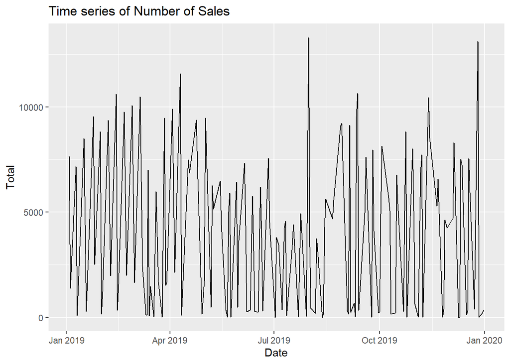

```r
iaLiquorSales %>%
  group_by(Date) %>%
  summarise(sales = sum(`Bottles Sold`)) %>%
  ggplot(iaLiquorSales, mapping = aes(Date, y = sales)) + geom_line() + scale_x_date() + xlab('Date') + ylab('Total') + ggtitle("Time series of Number of Sales")
```

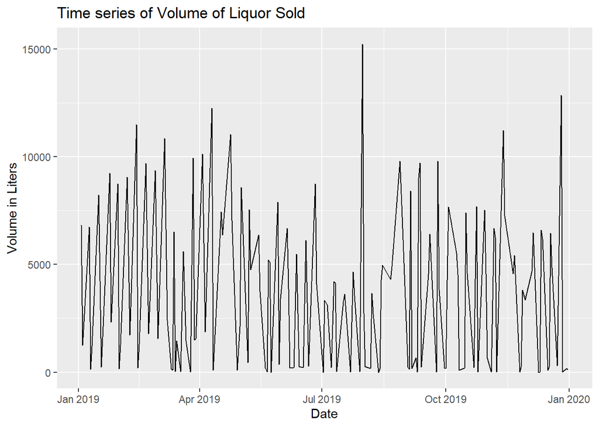

```r
iaLiquorSales %>%
  group_by(Date) %>%
  summarise(sold = sum(`Volume Sold (Liters)`)) %>%
  ggplot(iaLiquorSales, mapping = aes(Date, y = sold)) + geom_line() + scale_x_date() + xlab('Date') + ylab('Volume in Liters') + ggtitle("Time series of Volume of Liquor Sold")
```

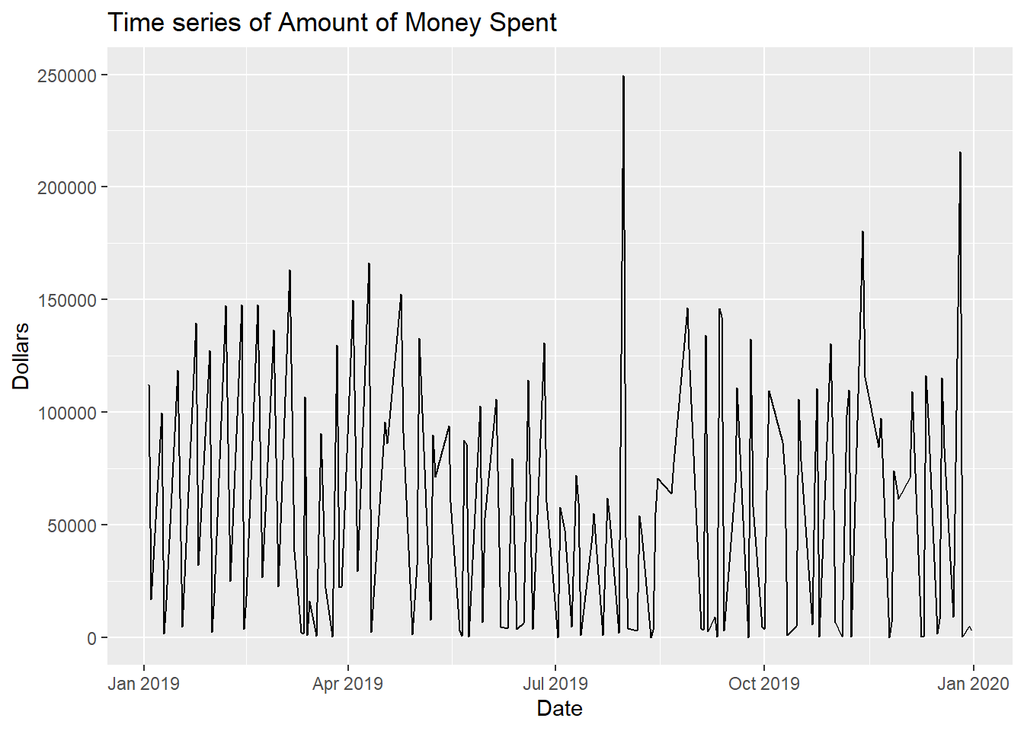

```r
iaLiquorSales %>%
  group_by(Date) %>%
  summarise(spent = sum(`Sale (Dollars)`)) %>%
  ggplot(iaLiquorSales, mapping = aes(Date, y = spent)) + geom_line() + scale_x_date() + xlab('Date') + ylab('Dollars') + ggtitle("Time series of Amount of Money Spent")
```

5. Plot volume sold by day (use a scatterplot of volume by day and facet by month). Discover trends with the help of `geom_smooth`. Describe any patterns.

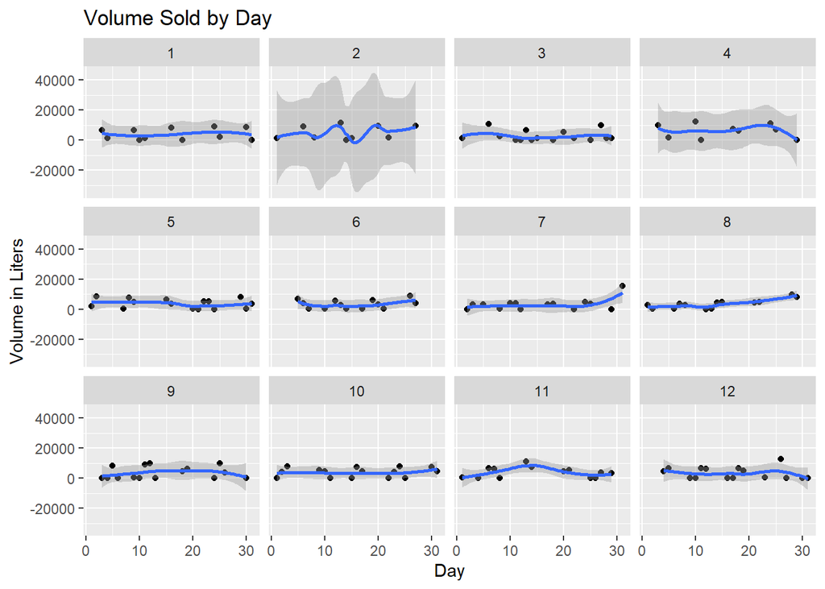

```r
iaLiquorSales %>%
  group_by(Month, Day) %>%
  summarise(sold = sum(`Volume Sold (Liters)`)) %>%
  ggplot(iaLiquorSales, mapping = aes(x = Day, y = sold)) + geom_point() + facet_wrap(vars(Month)) + geom_smooth(method = "loess", formula = y ~ x, size = 1) + xlab('Day') + ylab('Volume in Liters')  + ggtitle('Volume Sold by Day')
```

6. Find the dates for ISU football home games in Fall 2019. Can you see a pattern?

[figure not shown]

```r
# ISU home games: 8/31/19, 9/14/19, 9/21/19, 10/5/19, 10/26/19, 11/16/19, 11/23/19
homeGames <- c("08/31/2019", "09/14/2019", "09/21/2019", "10/05/2019", "10/26/2019", "11/16/2019", "11/23/2019")
iaLiquorSales$homeGames = (iaLiquorSales$Date %in% homeGames)
iaLiquorSales %>%
  ggplot(iaLiquorSales, mapping = aes(x = Date, y = `Sale (Dollars)`, fill = homeGames)) + geom_col() + xlab('Date') + ylab('Dollars') + ggtitle("Liqour Sales during 2019 ISU Football Home Games")
```

Note: your submission is supposed to be fully reproducible, i.e. the TA and I will ‘knit’ your submission in RStudio.